# HomeWork 2

# b

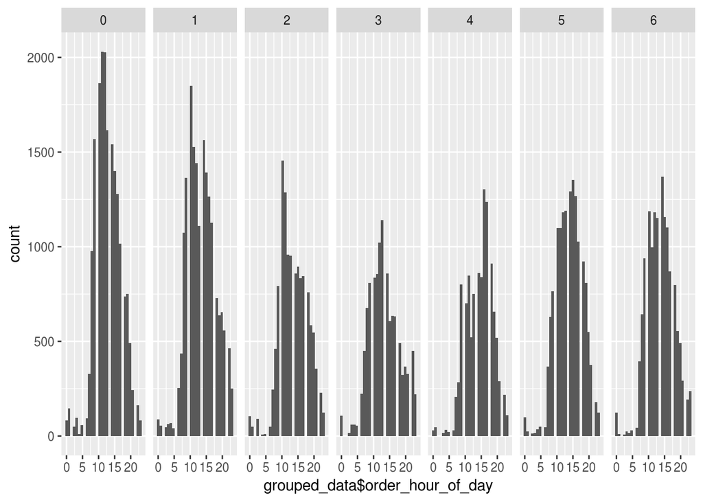

```r
library(ggplot2, warn.conflicts = FALSE)
grouped_data <- group_by(df, df$order_hour_of_day)

ggplot(grouped_data, aes(x=grouped_data$order_hour_of_day))+ geom_histogram() + facet_grid(. ~grouped_data$order_dow)
```

##c)

-its evident from the histogram that between 10 and 15 hours , there is high turn over of sales for the entire week and sunday having the highes turn over with over 2000 clients.

- its also evident from the histogram that the least sales in the week are made between 0 and 5 hours.
- its also evident that all the days of the week the sales tend take a similar patter.

## d)

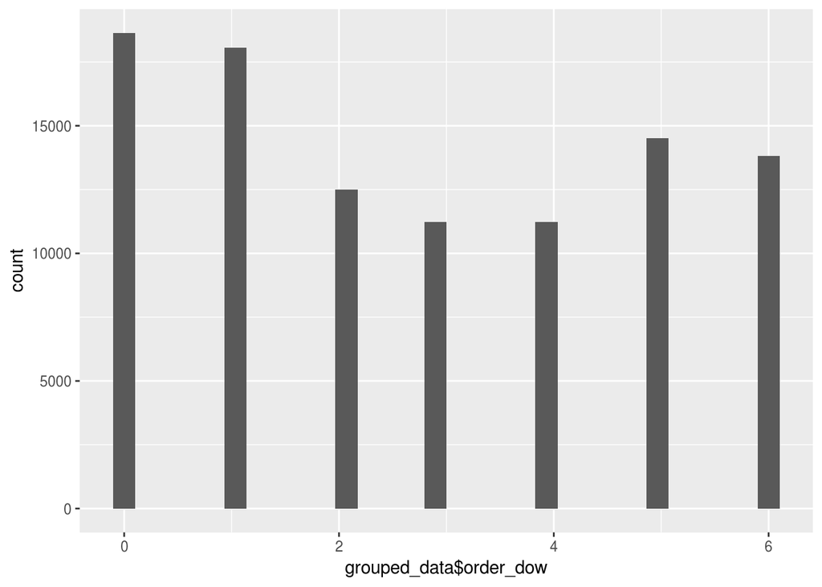

```r
grouped_data <- group_by(df, df$order_dow, df$department)

ggplot(grouped_data, aes(x=grouped_data$order_dow))+ geom_histogram()
```

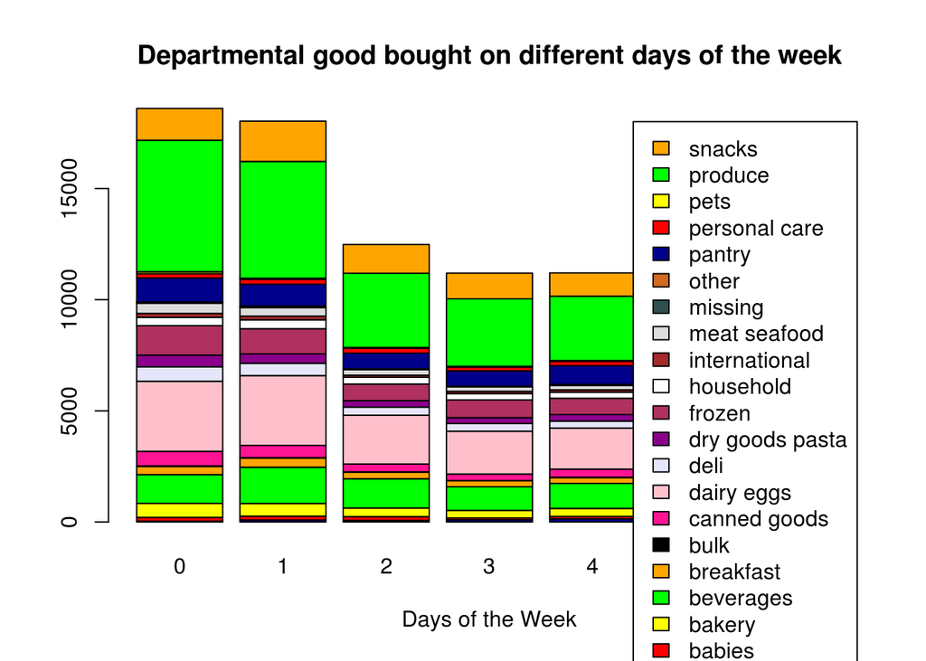

```r
counts <- table( df$department, df$order_dow)
barplot(counts, main="Departmental good bought on different days of the week",
  xlab="Days of the Week", col=c("darkblue","red","yellow","green","orange", "black","DeepPink","Pink", "Lavender","DarkMagenta","Maroon","white","brown","Gainsboro","DarkSlateGray","Chocolate"),
    legend = rownames(counts))
```

-from the stacked bar graph its obvious that the produce department has the highest sells through the week.

-diary eggs department has the second highest sells during the course of the weeek

-bulk department has the least sells through the week.